# TP 1: Analysis of prostate cancer data

OUAZZANI CHAHDI Mohammed

CHERKAOUI Ayoub

KERZAZI Achraf

## Exercise 1

```r
prostateCancer <- read.table("./prostate.data", header=T)
lcavol <- prostateCancer[1]
lcavol <- lcavol$lcavol
attach(prostateCancer)
```

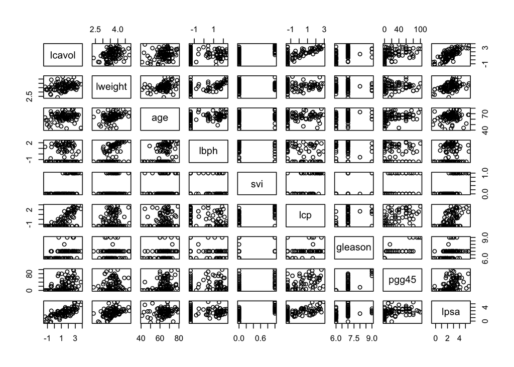

```r
prostateCancer <- data.frame(prostateCancer)[,-10]
pairs(prostateCancer)
```

## Exercise 2: Linear regression

#### (a)

the build of a predictive model for the lcavol variable

```r
model <- lm(formula = lcavol ~ . , data = prostateCancer )
```

considering gleason and svi as qualitative variables

```r
prostateCancer$gleason<-factor(prostateCancer$gleason)
prostateCancer$svi<-factor(prostateCancer$svi)
```

the mathematical equation of the regression model :

lcavol = $\beta_0$ + $\beta_1$ lpsa + $\beta_2$ lweight + $\beta_3$ age + $\beta_4$ lbph + $\beta_5$ svi + $\beta_6$ lcp + $\beta_7$ gleason + $\beta_8$ pgg45 + $\epsilon$

where $\beta_i$ is intrepreted as te average effect on lcavol of an unit increase in of the variable thar corresponds to $\beta_i$ while holding all other predictors fixed and $\epsilon$ is the noise variable that has zero mean, constant variance, and is uncorrolated with lcavol

```r
summary(model)
```

```
##
## Call:
## lm(formula = lcavol ~ ., data = prostateCancer)
##
## Residuals:
##      Min       1Q   Median       3Q      Max
## -1.91715 -0.48178 -0.04268  0.56056  1.86503
##
## Coefficients:
##              Estimate Std. Error t value Pr(>|t|)
## (Intercept) -2.420613   1.297027  -1.866   0.0653 .
## lweight     -0.025925   0.211817  -0.122   0.9029
## age          0.022113   0.011080   1.996   0.0491 *
## lbph        -0.093138   0.058058  -1.604   0.1122
## svi         -0.152966   0.254289  -0.602   0.5490
## lcp          0.367180   0.081814   4.488 2.17e-05 ***
## gleason      0.197249   0.154207   1.279   0.2042
## pgg45       -0.007117   0.004331  -1.643   0.1039
## lpsa         0.565826   0.088065   6.425 6.55e-09 ***
## ---
## Signif. codes:  0 '***' 0.001 '**' 0.01 '*' 0.05 '.' 0.1 ' ' 1
##
## Residual standard error: 0.7004 on 88 degrees of freedom
## Multiple R-squared:  0.6763, Adjusted R-squared:  0.6468
## F-statistic: 22.98 on 8 and 88 DF,  p-value: < 2.2e-16
```

```r
#cor(prostateCancer)
```

from the results of the regression and the tests we conclude that the variables lpsa and lcp has the more effect on lcavol

#### (b)

```r
confint(model)
```

```
##                     2.5 %      97.5 %
## (Intercept) -4.998182e+00 0.156956835
## lweight     -4.468660e-01 0.395015905
## age          9.392712e-05 0.044132450
## lbph        -2.085158e-01 0.022239024
## svi         -6.583119e-01 0.352378942
## lcp          2.045912e-01 0.529768658
## gleason     -1.092041e-01 0.503702531
## pgg45       -1.572416e-02 0.001489465
## lpsa         3.908162e-01 0.740835729
```

we see once again that lpsa and lcp have the more influence once because the left value of the confidence intervalle are the biggest and are far from zero compared to the others

#### (c)

```r
summary(model)
```

```
##
## Call:
## lm(formula = lcavol ~ ., data = prostateCancer)
##
## Residuals:
##      Min       1Q   Median       3Q      Max
## -1.91715 -0.48178 -0.04268  0.56056  1.86503
##
## Coefficients:
##              Estimate Std. Error t value Pr(>|t|)
## (Intercept) -2.420613   1.297027  -1.866   0.0653 .
## lweight     -0.025925   0.211817  -0.122   0.9029
## age          0.022113   0.011080   1.996   0.0491 *
## lbph        -0.093138   0.058058  -1.604   0.1122
## svi         -0.152966   0.254289  -0.602   0.5490
## lcp          0.367180   0.081814   4.488 2.17e-05 ***
## gleason      0.197249   0.154207   1.279   0.2042
## pgg45       -0.007117   0.004331  -1.643   0.1039
## lpsa         0.565826   0.088065   6.425 6.55e-09 ***
## ---
## Signif. codes:  0 '***' 0.001 '**' 0.01 '*' 0.05 '.' 0.1 ' ' 1
##
## Residual standard error: 0.7004 on 88 degrees of freedom
## Multiple R-squared:  0.6763, Adjusted R-squared:  0.6468
## F-statistic: 22.98 on 8 and 88 DF,  p-value: < 2.2e-16
```

```r
confint(model)
```

```
##                     2.5 %      97.5 %
## (Intercept) -4.998182e+00 0.156956835
## lweight     -4.468660e-01 0.395015905
## age          9.392712e-05 0.044132450
## lbph        -2.085158e-01 0.022239024
## svi         -6.583119e-01 0.352378942
## lcp          2.045912e-01 0.529768658
## gleason     -1.092041e-01 0.503702531
## pgg45       -1.572416e-02 0.001489465
## lpsa         3.908162e-01 0.740835729
```

#### (d)

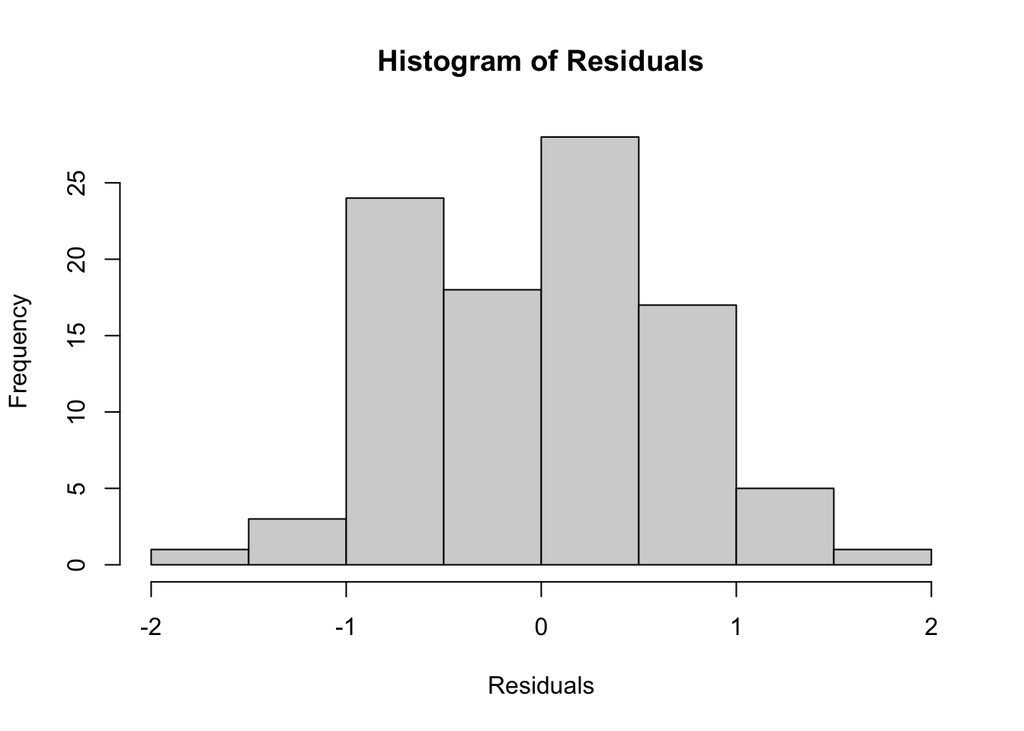

```r
predicted_data <- predict(model)
Residuals <- predicted_data - lcavol
hist(Residuals)
```

from the histogram we can see that the residual are centered around 0 and the distribution is more or less normally distributed left skewed, to ensure that it comes from a normal distribution we will use shapiro test

```r
shapiro.test(Residuals)
```

```
##
##  Shapiro-Wilk normality test
##
## data:  Residuals
## W = 0.98789, p-value = 0.5226
```

the p-value is bigger than 0.05 so we can say that it is normally distributed

The residual sum of squares :

```r
sum_squares <- sum(Residuals**2)
sum_squares
```

```
## [1] 43.1717
```

#### (e)

The optimality of the model

First the value if the sum_squares if not that big but to see how much our model is optimal we will compare to some basic models

the first model tha we will use predict always the same number which is the average of lcavol obtained from the data

the second model predict each time a random value from the intervalle that begins from the min value of lcavol and max value of lcavol

First model :

```r
moyenne_lcavol <- mean(lcavol)

predict_always_average <- c(1:length(lcavol))
for (i in 1:length(lcavol)){
  predict_always_average[i] <- moyenne_lcavol
}
diff2 <- predict_always_average  - lcavol
sum_sq <- sum(diff2**2)
sum_sq
```

```
## [1] 133.359
```

```r
#133
```

Second model :

```r
data_alea <- runif(97, min = min(lcavol), max = max(lcavol))
diff_alea <- data_alea - lcavol
alea_sum_squa <- sum(diff_alea**2)
alea_sum_squa
```

```
## [1] 352.1632
```

the sum of squares of both these models is much bigger so we can say that our model is good

#### (f)

```r
model_2 <-lm(formula = lcavol ~ lweight + age + lbph + svi+ gleason + pgg45 , data = prostateCancer )
summary(model_2)
```

```
##
## Call:
## lm(formula = lcavol ~ lweight + age + lbph + svi + gleason +
##     pgg45, data = prostateCancer)
##
## Residuals:
##      Min       1Q   Median       3Q      Max
## -1.84488 -0.48256 -0.01752  0.58918  2.21990
##
## Coefficients:
##               Estimate Std. Error t value Pr(>|t|)
## (Intercept) -1.9717103  1.1590310  -1.701 0.092442 .
## lweight      0.5849583  0.2591548   2.257 0.026472 *
## age          0.0072858  0.0146727   0.497 0.620739
## lbph        -0.0746433  0.0771750  -0.967 0.336097
## svi1         1.0245817  0.2714729   3.774 0.000291 ***
## gleason7     0.8007406  0.2744312   2.918 0.004473 **
## gleason8     0.6868720  0.9601171   0.715 0.476253
## gleason9     1.1726480  0.6444380   1.820 0.072214 .
## pgg45       -0.0004312  0.0056372  -0.076 0.939203
## ---
## Signif. codes:  0 '***' 0.001 '**' 0.01 '*' 0.05 '.' 0.1 ' ' 1
##
## Residual standard error: 0.9272 on 88 degrees of freedom
## Multiple R-squared:  0.4327, Adjusted R-squared:  0.3811
## F-statistic:  8.39 on 8 and 88 DF,  p-value: 2.11e-08
```

```r
confint(model_2)
```

```
##                   2.5 %     97.5 %
## (Intercept) -4.27504077 0.33162024
## lweight      0.06994253 1.09997407
## age         -0.02187299 0.03644465
## lbph        -0.22801250 0.07872586
## svi1         0.48508643 1.56407699
## gleason7     0.25536621 1.34611504
## gleason8    -1.22115901 2.59490299
## gleason9    -0.10803714 2.45333310
## pgg45       -0.01163391 0.01077153
```

```r
new_predicted_data <- predict(model_2)
diffe <- new_predicted_data - lcavol
sum_sq <- sum(diffe**2)
sum_sq
```

```
## [1] 75.65323
```

the remove of lpsa and lcp amplifies the effect of the other variables, we can see from the summary command for the new model the changments and how svi has become now the variable that has the more influence, which is confirmed by the confint command, but we can see that by generating new data using this new model and computing the sum of squares of residuals we get a bigger number than the one we got using the previous model that include lpsa and lcp

## Exercise 3:

#### (a).

```r
model0 <- lm(lcavol~1, data=prostateCancer)
model1 <- lm(lcavol~., data=prostateCancer[,c(1,4,9)])
model2 <- lm(lcavol~., data=prostateCancer[,c(1,2,9)])

summary(model0)
```

```
##
## Call:
## lm(formula = lcavol ~ 1, data = prostateCancer)
##
## Residuals:
##      Min       1Q   Median       3Q      Max
## -2.69708 -0.83719  0.09691  0.77703  2.47099
##
## Coefficients:
##             Estimate Std. Error t value Pr(>|t|)
## (Intercept)   1.3500     0.1197   11.28   <2e-16 ***
## ---
## Signif. codes:  0 '***' 0.001 '**' 0.01 '*' 0.05 '.' 0.1 ' ' 1
##
## Residual standard error: 1.179 on 96 degrees of freedom
```

```r
confint(model0)
```

```
##                2.5 %   97.5 %
## (Intercept) 1.112464 1.587555
```

```r
summary(model1)
```

```
##
## Call:
## lm(formula = lcavol ~ ., data = prostateCancer[, c(1, 4, 9)])
##
## Residuals:
##     Min      1Q  Median      3Q     Max
## -2.2998 -0.6245  0.0414  0.5564  1.6266
##
## Coefficients:
##             Estimate Std. Error t value Pr(>|t|)
## (Intercept) -0.54900    0.19459  -2.821  0.00583 **
## lbph        -0.08791    0.05709  -1.540  0.12697
## lpsa         0.76979    0.07176  10.728  < 2e-16 ***
## ---
## Signif. codes:  0 '***' 0.001 '**' 0.01 '*' 0.05 '.' 0.1 ' ' 1
##
## Residual standard error: 0.7983 on 94 degrees of freedom
## Multiple R-squared:  0.5508, Adjusted R-squared:  0.5412
## F-statistic: 57.62 on 2 and 94 DF,  p-value: < 2.2e-16
```

```r
confint(model1)
```

```
##                  2.5 %      97.5 %
## (Intercept) -0.9353489 -0.16264210
## lbph        -0.2012683  0.02544733
## lpsa         0.6273133  0.91225858
```

```r
summary(model2)
```

```
##
## Call:
## lm(formula = lcavol ~ ., data = prostateCancer[, c(1, 2, 9)])
##
## Residuals:
##      Min       1Q   Median       3Q      Max
## -2.06980 -0.60231  0.05406  0.53762  1.70037
##
## Coefficients:
##             Estimate Std. Error t value Pr(>|t|)
## (Intercept) -0.09570    0.71596  -0.134    0.894
## lweight     -0.12781    0.21327  -0.599    0.550
## lpsa         0.77047    0.07915   9.734 6.75e-16 ***
## ---
## Signif. codes:  0 '***' 0.001 '**' 0.01 '*' 0.05 '.' 0.1 ' ' 1
##
## Residual standard error: 0.8068 on 94 degrees of freedom
## Multiple R-squared:  0.5412, Adjusted R-squared:  0.5314
## F-statistic: 55.44 on 2 and 94 DF,  p-value: < 2.2e-16
```

```r
confint(model2)
```

```
##                  2.5 %    97.5 %
## (Intercept) -1.5172629 1.3258646
## lweight     -0.5512640 0.2956396
## lpsa         0.6133161 0.9276312
```

The first model with the parameter size of zero shows a higher residual standard error which indicates that the model is not accurate in comparison to the others.

The two models of size 2 show that the lpsa parameter is statistically significant in both cases, the residual error between the two is around the same value at 0.8. Furthermore, we can say that we are not capable to reject the null hypothesis for the two parameters lbph and lweight due to the high p-value they both suggest.

#### (b).

```r
list_cb <- combn(8, 2)
rss <- c()
best_estm <- Inf

for(e in seq(1, 28)) {
  model_i <- lm(lcavol~., data = prostateCancer[, c(1, list_cb[, c(e)][1] + 1, list_cb[, c(e)][2] + 1)])
  rss_i <- sum(model_i$residuals^2)
  rss <- c(rss, rss_i)
  if(best_estm > rss_i){
    best_estm <- rss_i
    best_set <- list_cb[, c(e)]
  }
}
dimnames(prostateCancer[, c(best_set + c(1, 1))])
```

```
## [[1]]
##  [1] "1"  "2"  "3"  "4"  "5"  "6"  "7"  "8"  "9"  "10" "11" "12" "13" "14" "15"
## [16] "16" "17" "18" "19" "20" "21" "22" "23" "24" "25" "26" "27" "28" "29" "30"
## [31] "31" "32" "33" "34" "35" "36" "37" "38" "39" "40" "41" "42" "43" "44" "45"
## [46] "46" "47" "48" "49" "50" "51" "52" "53" "54" "55" "56" "57" "58" "59" "60"
## [61] "61" "62" "63" "64" "65" "66" "67" "68" "69" "70" "71" "72" "73" "74" "75"
## [76] "76" "77" "78" "79" "80" "81" "82" "83" "84" "85" "86" "87" "88" "89" "90"
## [91] "91" "92" "93" "94" "95" "96" "97"
##
## [[2]]
## [1] "lcp"  "lpsa"
```

We therefore conclude that the best model of size 2 is the one containing the parameters lcp and lpsa by choosing the minimal residual sum of squares between all of the predictors possible combinations.

#### (c).

```r
rss <- c()
m_use <- matrix(0, nrow = 9, ncol = 9)

for(k in seq(0, 8)){
  list_cb <- combn(8, k)
  best_estm <- Inf
  n <- choose(8, k)
  best_set <- c(1)

  if(k>0){
    for(e in seq(1, n)) {
      pred_list <- c(1)
      if(k > 0){
        for(i in seq(1, k)){
          pred_list <- c(pred_list, list_cb[, c(e)][i])
        }
      }

      model_i <- lm(lcavol~., data = prostateCancer[, c(1, pred_list + 1)])
      rss_i <- sum(model_i$residuals^2)
      if(best_estm > rss_i){
        best_estm <- rss_i
        best_set <- list_cb[, c(e)]
      }
    }
    rss <- c(rss, rss_i)
    best_set <- best_set + 1
  }

  for(i in seq(0,k)){
    m_use[k+1 , best_set[i]] <- 1
  }
  if(k>0){
    print(best_set)
  }
}
```

```
## [1] 9
## [1] 6 9
## [1] 3 6 9
## [1] 3 4 6 9
## [1] 3 6 7 8 9
## [1] 3 4 6 7 8 9
## [1] 3 4 5 6 7 8 9
## [1] 2 3 4 5 6 7 8 9
```

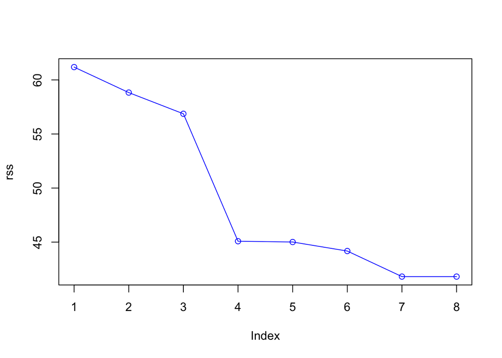

```r
plot(rss, col = "blue")
lines(rss, col = "blue")
```

We can see from the output that the best predictors for each k are the following:

$k = 0$ -

$k = 1$ lpsa

$k = 2$ lcp lpsa

$k = 3$ age lcp lpsa

$k = 4$ age lbph lcp lpsa

$k = 5$ age lcp gleason pgg45 lpsa

$k = 6$ age lbph lcp gleason pgg45 lpsa

$k = 7$ age lbph svi lcp gleason pgg45 lpsa

$k = 8$ lweight age lbph svi lcp gleason pgg45 lpsa

#### (d).

Minimizing the RSS results in choosing the maximum size of predictors which is accurate since receiving the maximum of information provided is the naive way to predict the variable. However, it does not give a well suited criteria to pick the optimal size of regression model. The RSS decreases as we add more variables to the model whether they are relevant or not which does not serve our quest in predicting the variable since it may not improve the model’s predective power or generalizability.

Selecting an optimal size of the regression model should balance between its complexity and its ability to fit the data and make accurate predictions. We may be able to achieve this by using model selection technique of Akaike Information Criterion AIC.

## Exercice 4:

#### (a).

In split validation we split the data to training and validation sets and we evaluate the model on validation data that was not used during the training. This allows us to avoid overfitting which occurs when we tweak the model to fit perfectly our data, but on unseen data the prediction are not necessarily accurate.

#### (b).

```r
#Choosing the validation set
valid <- seq(from = 3, to = nrow(prostateCancer), by = 3 )
```

#### (c).

The use of `lm(lcavol∼ . ,data=prostateCancer[!valid, c(1, i, j)])` creates a regression model using only data that won’t be used in the validation, which is the training data

```r
trained <- lm(lcavol~., data=prostateCancer[-valid, c(1, 6, 9)])
predictions_training <- predict(trained)
mean_training_error <- mean((prostateCancer[-valid, ]$lcavol - predictions_training)^2)
#Calculating the mean training error
mean_training_error
```

```
## [1] 0.4616663
```

#### (d).

```r
#We predict the results for data not used in the training
predictions_validation <- predict(trained, prostateCancer[valid, ])
mean_validation_error <- mean((prostateCancer[valid, ]$lcavol - predictions_validation)^2)
mean_validation_error
```

```
## [1] 0.5672302
```

#### (e).

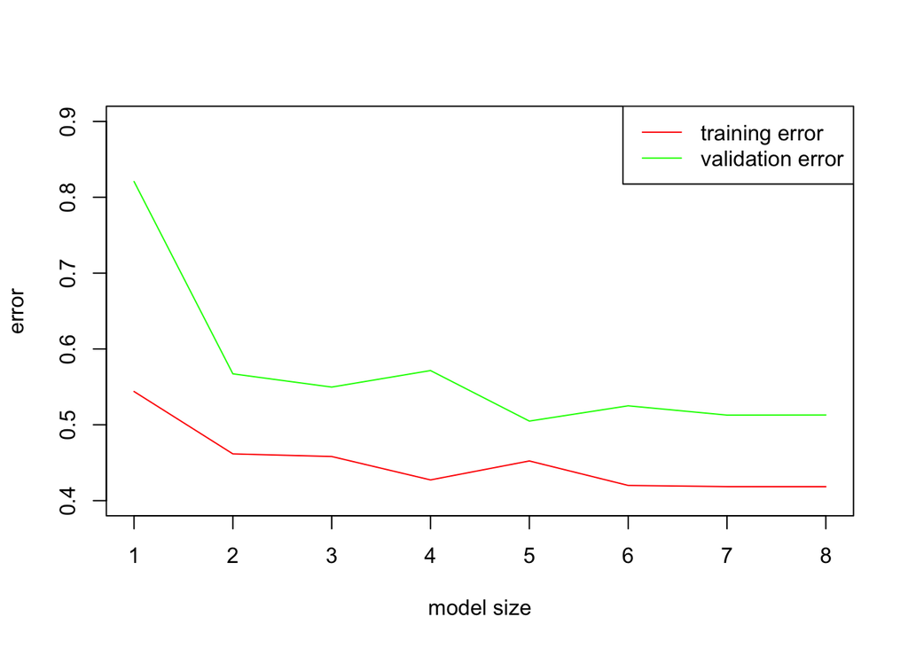

```r
validation_errors <- c()
training_errors <- c()
for (k in c(2:9)){
  trained_k <- lm(prostateCancer[-valid,]$lcavol~., data=prostateCancer[-valid, c(1, which(m_use[k,] == 1))])

  predictions_validation_k <- predict(trained_k, prostateCancer[valid, ])
  predictions_train_k <- predict(trained_k)


  mean_validation_error_k <- mean((prostateCancer[valid, ]$lcavol - predictions_validation_k)^2)
  mean_train_error_k <- mean((prostateCancer[-valid, ]$lcavol - predictions_train_k)^2)
  training_errors <- c(training_errors, mean_train_error_k)
  validation_errors  <- c(validation_errors, mean_validation_error_k)
}

plot(seq(1:8), training_errors, type = "l", col = "red", xlab = "model size", ylab = "error", ylim = c(0.4, 0.9))
lines(seq(1:8), validation_errors, col = "green")
legend("topright", legend = c("training error", "validation error"), col = c("red", "green"), lty = 1)
```

We can see that the training error remains low. That’s because the more predictors we use the more we fit our data, however this is cannot be used to conclude the optimal model size. Thus we use the validation error to select the best model size and it appears to be the model with 5 predictors.

#### (f).

The main problem that could occur is the fact that the choice of the training set is random and it could end up in a set that doesn’t provide good training for the model To address this problem we can use cross validation technique

```r
# Size of dataset
#We use 80% percent of the data for cross validation and we keep the last 20% percent for testing
N_cv = nrow(prostateCancer)
K <- 5
#loop through the sizes of the model
cvError_size <- vector (mode="numeric", length=8)
for (p in 2:9){
  cvError_k <- vector (mode="numeric", length=K)
  #loop through the folds
  for (k in 1:K){
    # choose the indices of the samples for the fold k-th
    id_val <- k + seq(0, N_cv-K, by=K)
    id_val <- setdiff(id_val, 37)
    # get the training dataset
    f <- lm(prostateCancer[-id_val, ]$lcavol~., data=prostateCancer[-id_val, c(1, which(m_use[p,] == 1))])
    # get the prediction error to estimate data from validation set
    data_to_predict = prostateCancer[id_val, c(1, which(m_use[p,] == 1))]
    error <- predict(f, data_to_predict) - prostateCancer[id_val, ]$lcavol
    # calculate the mean squared error for this fold
    cvError_k[k] <- mean(error^2)
  }
  cvError_size[p]  <- mean(cvError_k)
}
optimal_size <- which.min(cvError_size[-1])
#Optimal size model
optimal_size
```

```
## [1] 5
```

The result for the best model size is 5 which is similar to the split-validation results. But the two methods could differ with the data

### Exercise 5 : Conclusion

To apply the model, we split into training and validations sets and the quality can be deduced from the validation error.

```r
#We predict the results for data not used in the training

trained <- lm(lcavol~., data=prostateCancer[-valid, c(1, which(m_use[5, ] ==1))])
predictions_validation <- predict(trained, prostateCancer[valid, ])
mean_validation_error <- mean((prostateCancer[valid, ]$lcavol - predictions_validation)^2)
mean_validation_error
```

```
## [1] 0.5715349
```